# Normal Probabilities

- `dnorm()`: P(X = x) = height of normal distribution
- `pnorm()`:
  - lower.tail = TRUE (default) $\Rightarrow \ \ P(X \leq x) = F(x)$
  - lower.tail = FALSE $\rightarrow \ \ P(X \geq x)$
- `qnorm()`: Inverse normal - Find c, such that $P(X \leq c) = p$
- `rnorm()`: Random samples of size n
1. Let $Z \sim N(0,1)$. Compute the following probabilities.
   1. $P(Z < 1.35)$ = 0.911492

```r
pnorm(1.35)
```

```
## [1] 0.911492
```

2. $P(Z > -0.27)$

```r
pnorm(-0.27, lower.tail = FALSE)
```

```
## [1] 0.6064199
```

3. $P(-0.1 < Z < 1.4)$

```r
pnorm(1.4) - pnorm(-0.1)
```

```
## [1] 0.4590712
```

2. Next, find the value $c$ such that:
   1. $P(Z < c) = 0.025$

```r
qnorm(0.025)
```

```
## [1] -1.959964
```

2. $P(X > c) = 0.05$ where $X \sim N(10, 5)$

```r
qnorm(0.05, 10, 5, lower.tail = FALSE)
```

```
## [1] 18.22427
```

3. $P(-c < Z < c) = 0.99$.

   ```
   $c$ = 2.5758293
   ```

```r
# qnorm(0.995)
# qnorm(0.005, lower.tail = FALSE)
qnorm(0.005)
```

```
## [1] -2.575829
```

3. Generate a random sample of size $n = 1000$ from a standard normal distribution. Use the `graphics` package to plot the histogram. Make sure your plot is well-labeled!

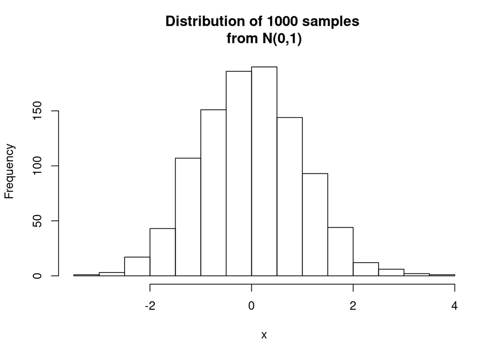

```r
x <- rnorm(1000)
hist(x,
     main = "Distribution of 1000 samples \nfrom N(0,1)",
     xlab = "x",
     ylab = "Frequency")
```

4. Compare your histogram to at least one other person’s in the class. Are they the same or different? Why is this the case?
5. Use the `graphics` package to plot the pdf of a standard normal distribution.

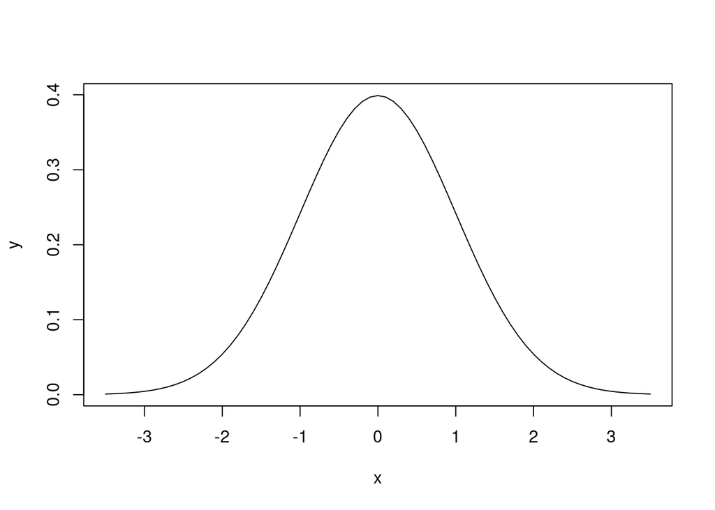

```r
x <- seq(-3.5, 3.5, 0.1)
y <- dnorm(x)
plot(x, y, type = "l")
```

6. Plot the following 3 distributions in a single figure. $X \sim N(10, 3)$, $X\sim N(10,5)$, and $X \sim N(10, 7)$.

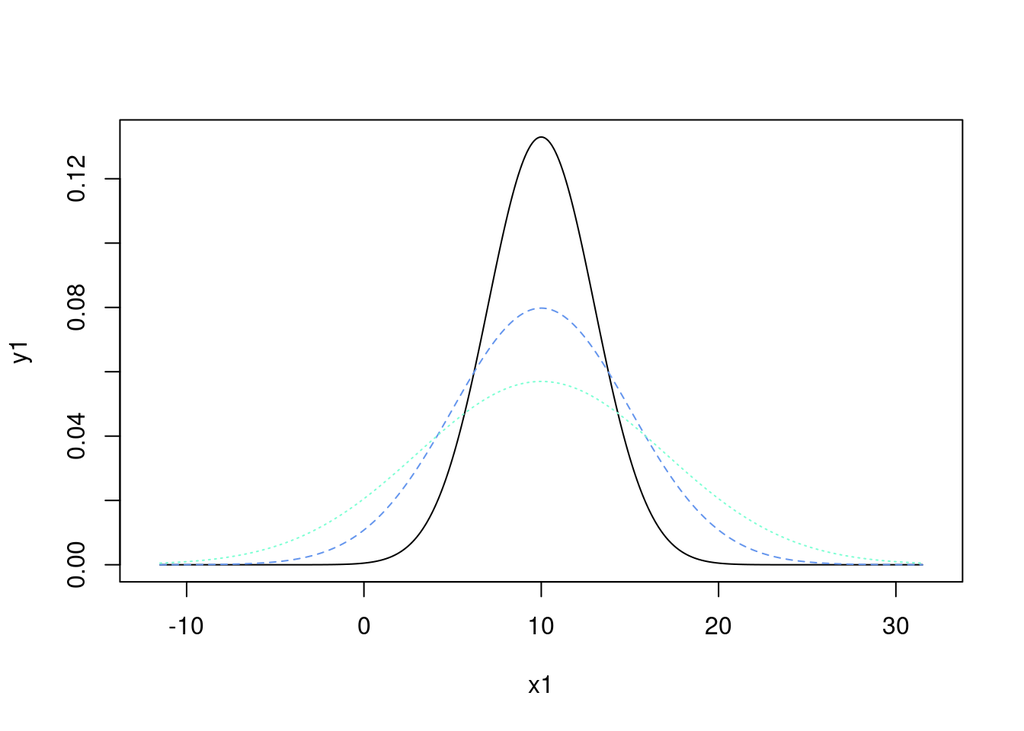

```r
x1 <- seq(-11.5, 31.5, 0.1) # N(10, 3)
y1 <- dnorm(x1, mean = 10, sd = 3)

x2 <- seq(-11.5, 31.5, 0.1) #N(10, 5)
y2 <- dnorm(x2, mean = 10, sd = 5)

x3 <- seq(-11.5, 31.5, 0.1) #N(10, 7)
y3 <- dnorm(x3, mean = 10, sd = 7)

plot(x1, y1, type = "l", xlim = c(-12, 32))
lines(x2, y2, lty = 2, col = "cornflowerblue")
lines(x3, y3, lty = 3, col = "aquamarine")
```

7. The following questions refer to the `email` dataset from the `openintro` package.
   1. Plot the distribution of the variable `num_char` using `ggplot2`.

```r
library(openintro)
library(ggplot2)
library(dplyr)

data("email")
```

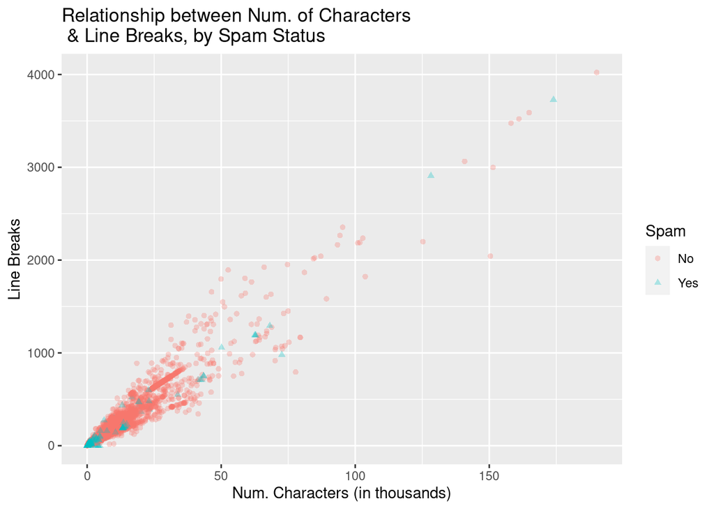

```r
email %>%
  mutate(spam = factor(spam, labels = c("No", "Yes"))) %>%
  ggplot(aes(x = num_char,
             y = line_breaks,
             col = spam, shape = spam)) +
  geom_point(alpha = 0.3) +
  labs(title = "Relationship between Num. of Characters\n & Line Breaks, by Spam Status",
       x = "Num. Characters (in thousands)",
       y = "Line Breaks",
       col = "Spam",
       shape = "Spam")
```

2. Create a qq-plot to assess the normality of this variable.

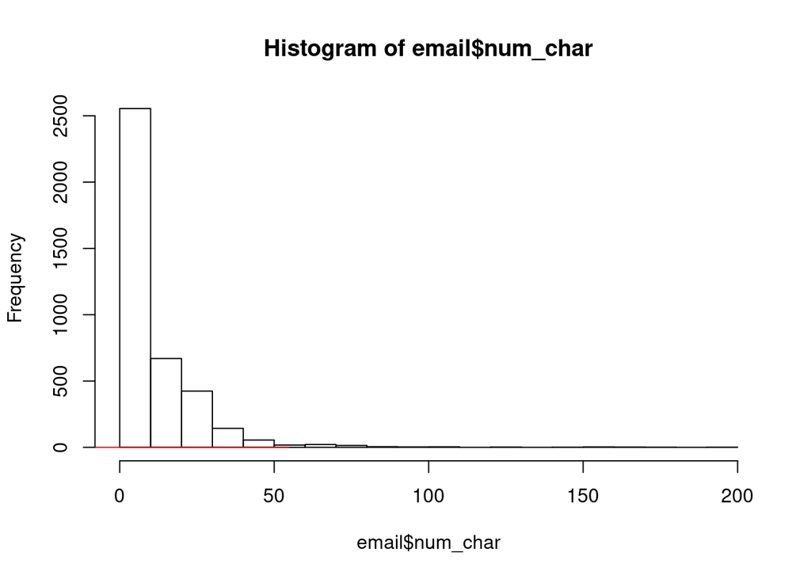

```r
hist(email$num_char, breaks = 15)

mn <- mean(email$num_char)
std_dev <- sd(email$num_char)

x <- seq(mn-3*std_dev, mn+3*std_dev, 0.1)
y <- dnorm(x, mean = mn, sd = std_dev)

hist(email$num_char, breaks = 15)
lines(x, y, col = "red")
```

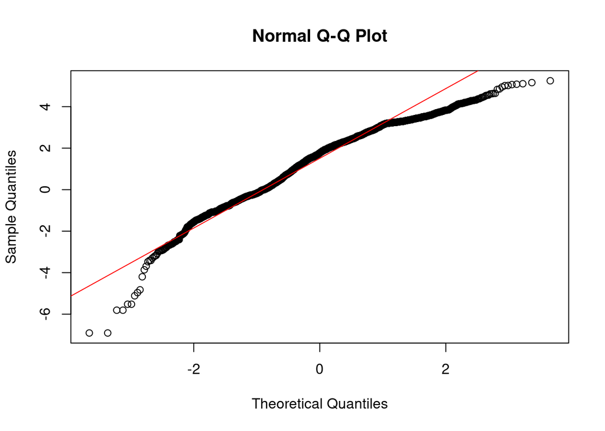

```r
qqnorm(log(email$num_char))
qqline(log(email$num_char), col = "red")
```

8. Simulations. Simulate three random samples from a standard normal random variables: one with a sample size n = 10, n = 30, and n = 100. Assess the normality of each of the samples. What do you notice? Why do you think that is happening?